# Data Discovery

```python
import pandas as pd

titanic_data = pd.read_csv('titanic_data.csv')

titanic_data.head()
```

|  | PassengerId | Survived | Pclass | Name | Sex | Age | SibSp | Parch | Ticket | Fare | Cabin | Embarked |
| --- | --- | --- | --- | --- | --- | --- | --- | --- | --- | --- | --- | --- |
| 0 | 1 | 0 | 3 | Braund, Mr. Owen Harris | male | 22 | 1 | 0 | A/5 21171 | 7.2500 | NaN | S |
| 1 | 2 | 1 | 1 | Cumings, Mrs. John Bradley (Florence Briggs Th... | female | 38 | 1 | 0 | PC 17599 | 71.2833 | C85 | C |
| 2 | 3 | 1 | 3 | Heikkinen, Miss. Laina | female | 26 | 0 | 0 | STON/O2. 3101282 | 7.9250 | NaN | S |
| 3 | 4 | 1 | 1 | Futrelle, Mrs. Jacques Heath (Lily May Peel) | female | 35 | 1 | 0 | 113803 | 53.1000 | C123 | S |
| 4 | 5 | 0 | 3 | Allen, Mr. William Henry | male | 35 | 0 | 0 | 373450 | 8.0500 | NaN | S |

```python
titanic_data.info()
```

```
<class 'pandas.core.frame.DataFrame'>
Int64Index: 891 entries, 0 to 890
Data columns (total 12 columns):
PassengerId    891 non-null int64
Survived       891 non-null int64
Pclass         891 non-null int64
Name           891 non-null object
Sex            891 non-null object
Age            714 non-null float64
SibSp          891 non-null int64
Parch          891 non-null int64
Ticket         891 non-null object
Fare           891 non-null float64
Cabin          204 non-null object
Embarked       889 non-null object
dtypes: float64(2), int64(5), object(5)
memory usage: 90.5+ KB
```

# Statistical Test Formulation

I'm interested to know if members of different Pclass have different chance to survive. in other word I want to know if the *Pclass* variable and the *Survived* variable are independent.

For this test the dependent variable is the *Survived* variable and the independent variable is the *Pclass* variable.

The two variables affected in this test are categorical variables and we are comparing proportions so a suited statistical test for this task is a chi-squared test.

**Null hypothesis :** The survival rate is independent of the class. In proportion the number of people who survived is equivalent for each class. p1 = p2 = p3 where p1, p2, p3 represent the proportions respectively for the class 1, 2 and 3.

**Alternative hypothesis :** The survival rate is dependent of the class. In proportion the number of people who survived is different between class. p1 ≠ p2 ≠ p3

**Assumption** :

- Expected proportions are large enough (>5).
- Each observation is independant of others.

We set the significance level to be 0.1. Given that we are considering a chi-squared test we are dealing with a one-sided test.

# Exploratory Data Analysis

Since we are only interested by the *Pclass* variable and the *Survived* variable I first create a second dataframe to keep only these variables. For the rest of the analysis I only consider this dataframe.

From the Data Discovery step we can observe that the two variables don't contain null values so we don't need to perform additional steps to clean the data.

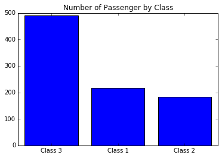

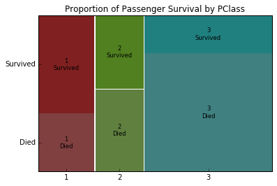

```python
# %pylab inline
%matplotlib inline
import pylab as pl
import matplotlib.pyplot as plt
from statsmodels.graphics.mosaicplot import mosaic
from pandas import crosstab
import numpy as np

reduce_titanic_data = pd.DataFrame()
reduce_titanic_data['Survived'] = pd.Series(pd.Categorical.from_codes(titanic_data['Survived'], categories=["Died", "Survived"]))
reduce_titanic_data['Pclass'] = titanic_data['Pclass']

plt.figure()
plt.bar(np.unique(reduce_titanic_data['Pclass']), reduce_titanic_data['Pclass'].value_counts(), align='center')
plt.xticks(np.unique(reduce_titanic_data['Pclass']), ['Class 3', 'Class 1', 'Class 2'])
plt.title('Number of Passenger by Class')
plt.show()

plt.figure()
mosaic = mosaic(reduce_titanic_data, ['Pclass', 'Survived'], title='Proportion of Passenger Survival by PClass')
plt.show()

crosstab = crosstab(reduce_titanic_data['Survived'], reduce_titanic_data['Pclass'])
```

```
                                                Contingency Table
```

|  | Class 1 | Class 2 | Class 3 | Total |
| --- | --- | --- | --- | --- |
| **Died** | 80 | 97 | 372 | 549 |
| **Survived** | 136 | 87 | 119 | 342 |
| **Total** | 216 | 184 | 491 | 891 |

# Statistical Test

```python
from scipy.stats import chisquare

survived_frequencies = crosstab.as_matrix().flatten() / [ crosstab[1][0] + crosstab[1][1], crosstab[2][0] + crosstab[2][1], crosstab[3][0] + crosstab[3][1], crosstab[1][0] + crosstab[1][1], crosstab[2][0] + crosstab[2][1], crosstab[3][0] + crosstab[3][1] ]
expected_frequencies = np.empty(6)
expected_frequencies[0:3] = ( (crosstab[1][0] + crosstab[2][0] + crosstab[3][0])/crosstab.sum().sum())
expected_frequencies[3:] = ( (crosstab[1][1] + crosstab[2][1] + crosstab[3][1])/crosstab.sum().sum())

survived_frequencies = survived_frequencies * 100
expected_frequencies = expected_frequencies * 100

chisq, p  = chisquare(survived_frequencies, expected_frequencies)
```

# Results Interpretation

This result confirm my expectation that members of different class are not treated equally. Further explorations could investigate what cause this difference.

# References

- http://sites.stat.psu.edu/~mga/401/tables/Chi-square-table.pdf
- https://en.wikipedia.org/wiki/Chi-squared_test